# Multivariate Linear Regression at Sephora

Rachel Schwartz

# 1 Introduction

Multiple Linear Regression is a statistical method used to model the relationship between two or more independent variables and a dependent variable by fitting a linear equation. You are probably familiar with the formulation of a univariate linear regression:

$$Y = \beta_0 + \beta_1 X_1 + \epsilon$$

Where:

1. $Y$ is the dependent variable (also known as the **response**)
2. $X_1, X_2, \dots, X_n$ are the **predictor** variables aka **features**
3. $\beta_0$ is the **intercept**
4. $\beta_1$ is the the **coefficients*
5. $\epsilon$ is the **error** term, also known as a **residual**

In this primer, we will extend univariate regression to take into account multiple predictor variables.

# 2 Simulating a Multivariate Dataset

Yesenia is a Sephora employee who spends most of her shifts matching foundation to customers’ skin complexion. This is a time consuming process by hand. Yesenia decides to build a statistical model to quickly predict the best foundation shade for any customer based on their complexion, undertone, and the oil content of their skin. Let’s imagine she has compiled a **training dataset** of customers, their aformentioned features, and their self-reported perfect foundation match (this will be our response variable). Let’s now simulate some data to represent this scenario:

```r
set.seed(123)
n <- 30 # we're sampling from 30 Sephora customers

# Simulate training data
skin_complexion <- rnorm(n, mean = 50, sd = 5)  # Complexion ~ N(50, 25)
skin_type <- factor(sample(c("Oily", "Dry", "Combination"), n, replace = TRUE))
undertone <- rnorm(n, mean = 0, sd = 1)  # Undertone ~ N(0,1)

# Each categorical may have a different coefficient
# something about this is broken
skin_type_effect <- c(Oily = -5, Combination = 0, Dry = 20)

# Simulate foundation shade from linear combo of predictors with normally distributed errors
# Let this be the matched foundation shade by the Sephora employee
foundation_shade <- 0.5 * skin_complexion +
                    skin_type_effect[as.character(skin_type)] +  # correct indexing
                    3 * undertone +
                    rnorm(n, sd = 2)  # e ~ N(0,4)
# make sure variance doesn't exceed effect sizes

# Response = foundation_shade
df <- data.frame(
  foundation_shade,
  skin_complexion,
  skin_type,
  undertone
)

head(df)
```

```
##   foundation_shade skin_complexion   skin_type   undertone
## 1         18.07092        47.19762        Oily -0.08336907
## 2         25.19604        48.84911 Combination  0.25331851
## 3         24.58169        57.79354        Oily -0.02854676
## 4         44.30634        50.35254         Dry -0.04287046
## 5         25.71778        50.64644        Oily  1.36860228
## 6         23.16938        58.57532        Oily -0.22577099
```

Here we can see that the overall foundation shade is represented as a **continuous** response variable which depends on continuous variables (skin complexion and undertone) as well as a **categorical** variable (skin type). To better visualize the data, let’s plot it in a three dimensional space:

```r
# Visualize effect of predictors
# Define consistent colors
# make this random


default_colors <- c("#e78ac3", "#a6cee3", "#d4b9da")  # Soft pink, light blue, peach
type_colors <- setNames(default_colors[seq_along(levels(df$skin_type))], levels(df$skin_type))


p <- plot_ly(df,
        x = ~skin_complexion,
        y = ~undertone,
        z = ~foundation_shade,
        type = "scatter3d",
        mode = "markers",
        color = ~skin_type,  # map to skin_type for legend
        marker = list(size = 4),
        colors = type_colors
      ) %>%
  layout(scene = list(
    xaxis = list(title = "Skin Complexion"),
    yaxis = list(title = "Undertone"),
    zaxis = list(title = "Foundation Shade")
  ))

p
```

[interactive chart not shown]

When we fit a linear model in two dimensions, we assume that the response variable is approximately linear; that is, it lies on a line (think $Y = Mx + B$). In a univariate linear model, we find the coefficient $M$ (often represented as $\beta_1$) and intercept $B$ (often represented as $\beta_0$) which transforms the predictor vector into a line best approximating the response variable $Y$:

$$y = \beta_0 + \beta_1 x_1 + \epsilon$$

In a multiple linear regression, we assume that the response variable lies approximately on a **hyperplane** instead of a line (or, as we will see, three hyperplanes). This is formulated as:

$$Y = \beta_0 + \beta_1 X_1 + \beta_2 X_2 + \dots + \beta_n X_n + \epsilon$$

Where $\beta_1, \beta_2, \dots, \beta_n$ are the **coefficients** which define this hyperplane.

When we fit a linear model, we solve for *estimates* the coefficients $\beta_1, \beta_2, \dots, \beta_n$. Their linear combination gives us the predicted or *fitted* value of the response variable. Because these are estimated from the sample $n$, they are represented using a **hat**, $\hat{}$ to distinguish them from the true population statistics.

- $\hat{Y}$: the fitted value of the response variable
- $\hat{\beta}_0, \hat{\beta}_1, \dots, \hat{\beta}_n$: the estimated coefficients and intercept

The fitted model is:

$$\hat{Y} = \hat{\beta}_0 + \hat{\beta}_1 X_1 + \hat{\beta}_2 X_2 + \dots
+ \hat{\beta}_n X_n$$

Notice that the error term (residual) is absent. This is the difference between the observed and fitted values:

$$\boldsymbol{\varepsilon} = {Y} - \hat{Y}$$

Therefore:

$${Y} = \hat{\beta}_0 + \hat{\beta}_1 X_1 + \hat{\beta}_2 X_2 + \dots +
\hat{\beta}_n X_n + \boldsymbol{\varepsilon}$$

We solve for coefficients by minimizing this residual, a.k.a. our *loss function*. Once we find our $\beta$ values, we can use them to predict a response (in this case, a foundation shade) for unseen customers.

# 3 Solving a Multivariate Linear Equation

The procedure for finding the coefficients $\beta_0, \beta_1, \ldots \beta_n$ to projected our predictors onto a hyperplane is the same as for univariate linear regression, where they are projected onto a line. This procedure is known as* **Ordinary Least Squares (OLS)**.

## 3.1 The Design Matrix

To solve OLS, we will need to use matrix algebra. Instead of a single predictor vector $x$, we have a matrix of predictor variables $X$ called the **design matrix**. We can simplify all the coefficients $\beta_1, \beta_2, \dots, \beta_n$ into a vector $\boldsymbol{\beta}$, and write the model in matrix form:

$$Y = X \boldsymbol{\hat\beta} + \boldsymbol{\varepsilon} = \hat{Y} +
\boldsymbol{\varepsilon}$$

In full matrix notation:

$$\begin{bmatrix}
y_1 \\
y_2 \\
\vdots \\
y_m
\end{bmatrix}
=
\begin{bmatrix}
1 & x_{11} & x_{12} & \dots & x_{1n} \\
1 & x_{21} & x_{22} & \dots & x_{2n} \\
\vdots & \vdots & \vdots & \ddots & \vdots \\
1 & x_{m1} & x_{m2} & \dots & x_{mn}
\end{bmatrix}
\begin{bmatrix}
\beta_0 \\
\beta_1 \\
\beta_2 \\
\vdots \\
\beta_n
\end{bmatrix}
+
\begin{bmatrix}
\varepsilon_1 \\
\varepsilon_2 \\
\vdots \\
\varepsilon_m
\end{bmatrix}$$

Where:

- $\mathbf{Y}$ is the $n \times 1$ vector of observed responses
- $\mathbf{X}$ is the $n \times (p+1)$ design matrix
- $\boldsymbol{\beta}$ is the $(p+1) \times 1$ vector of coefficients
- $\boldsymbol{\varepsilon}$ is the $n \times 1$ vector of errors

The design matrix is very similar to our data itself `df` with some important transformations. To demonstrate, let’s fit the linear model and look at its design matrix:

```r
# Fit full model including skin_type (with Combination as baseline)
# Specify a model using a linear formula of predictors
model <- lm(foundation_shade ~ skin_complexion + undertone + skin_type, data = df)
design=model.matrix(model)
head(design, 10)
```

```
##    (Intercept) skin_complexion   undertone skin_typeDry skin_typeOily
## 1            1        47.19762 -0.08336907            0             1
## 2            1        48.84911  0.25331851            0             0
## 3            1        57.79354 -0.02854676            0             1
## 4            1        50.35254 -0.04287046            1             0
## 5            1        50.64644  1.36860228            0             1
## 6            1        58.57532 -0.22577099            0             1
## 7            1        52.30458  1.51647060            0             0
## 8            1        43.67469 -1.54875280            0             1
## 9            1        46.56574  0.58461375            1             0
## 10           1        47.77169  0.12385424            0             1
```

As you can see, there are 5 columns of our design matrix, although we only have 3 predictors. Each row of our design matrix represents a customer, and each column represents his or her complexion, undertone, and skin type as well as an **intercept** term.

The intercept (also called $\beta_0$) is the baseline value of the response variable when all predictors are zero. To include the intercept in our linear model, we add a column of 1s to the design matrix. This allows the model to learn the intercept as a coefficient just like any other variable.

Because skin type is a **categorical** variable, it is **one-hot encoded**. That means each category (e.g., oily, dry, combination) is turned into its own binary column:

- `"Oily"` → [0, 1, 0]
- `"Dry"` → [1, 0, 0]
- `"Combination"` → [0, 0, 1]

Only one of these columns is 1 for each row (customer), and the others are 0. This lets the linear model assign a different coefficient to each skin type.

You may notice that **combination** skin is absent from the columns of the design matrix. When encoding categorical variables, one level is dropped to avoid **linear dependency**. This means that once we know the values for oily and dry skin, we can deduce the factor value for “combination skin. In other words, the columns for oily, dry, and combination skin types are **linearly dependent**. As we will see later, linear dependency prevents us from fitting the model. One categorical column must always be”dropped” to avoid this.

Any level can be dropped to avoid linear dependency. is known as the **reference level**. In this case, **combination** skin is the reference, and its effect is absorbed into the intercept $\beta_0$. In full matrix notation:

$$\hat{Y} = X\beta =
\begin{bmatrix}
1 & \text{complexion}_1 & \text{undertone}_1 & 1 & 0 \\
1 & \text{complexion}_2 & \text{undertone}_2 & 0 & 1 \\
\vdots & \vdots & \vdots & \vdots & \vdots \\
1 & \text{complexion}_n & \text{undertone}_n & 0 & 0 \\
\end{bmatrix}
\begin{bmatrix}
\beta_0 \\
\beta_{\text{complexion}} \\
\beta_{\text{undertone}} \\
\beta_{\text{dry}} \\
\beta_{\text{oily}} \\
\end{bmatrix}
=
\begin{bmatrix}
\hat{foundation}_1 \\
\hat{foundation}_2 \\
\vdots \\
\hat{foundation}_n
\end{bmatrix}$$

## 3.2 Matrix Multiplication

Columns of the design matrix represent the values of our predictor variables. When we multiply the design matrix by our coefficient vector, each predictor vector (column) is scaled by its corresponding coefficient. Columns are then added to obtain fitted values $\hat{Y}$. For an overview of matrix arithmetic, see (“Matrix Arithmetic - Matrix Algebra Review,” n.d.).

## 3.3 The Normal Equation

As previously mentioned, we want to minimize:

$$\varepsilon = Y - \hat{Y}$$

Where $Y$ is the true foundation match and $\hat{Y}$ is the predicted foundation match.

We generalize this to the **Residual Sum of Squares (RSS)** across all predictions:

$$RSS = \sum_{i=1}^{n} (y_i - \hat{y}_i)^2 = \| Y - X
\boldsymbol{\hat\beta} \|^2$$

Where $\| Y - X \boldsymbol{\hat\beta} \|^2$ is the **L2 norm** of the residual vector. The **norm** is the distance between any point in an N-dimensional space and the origin. We use the norm in this case to ignore +/- signs in the residual vector.

It turns out that there is a unique solution to finding the value of $\boldsymbol{\hat\beta}$ that minimizes the norm of the residuals. The shortest distance between the true values $Y$ and the fitted values $\hat{Y}$ occurs when we **orthogonally project** $Y$ onto the column space of $X$. In other words, we’re finding $\hat{Y} \in \text{Col}(X)$ such that the residual vector $Y - X\boldsymbol{\hat\beta}$ is orthogonal (perpendicular, $90^o$) to every column of $X$. We find this by multiplying the residual vector by the transpose of the design and setting to 0:
$$X^T (Y - X\boldsymbol{\hat\beta}) = 0$$

By the property of distributivity:

$$X^TY - (X^TX)\boldsymbol{\hat\beta} = 0$$

Solving for $\boldsymbol{\hat\beta}$ gives us the **Normal Equation**:

$$X^T X \boldsymbol{\hat\beta} = X^T Y$$

This provides the exact solution for $\boldsymbol{\hat\beta}$, assuming $X^T X$ is **invertible**:

$$\boldsymbol{\hat\beta} = (X^T X)^{-1} X^T Y$$

Some important terms:

1. Matrix Inverse - The inverse of a matrix $A$, written $A^{-1}$, satisfies $AA^{-1} = I$, where $I$ is the identity matrix.
2. Hat Matrix - $X{\beta} = X(X^T X)^{-1} X^T Y = HY$ where $H$ is that “hat” matrix as it puts a “hat” on $Y$ (also known as the “projection matrix”).
3. Linear Independence - columns of $X$ must be linearly independent so $X^T X$ is invertible. This is why we must drop `skin_typeCombination` from our design matrix $X$.

## 3.4 Geometric Proof

How do we know that the orthogonal projection of $Y$ onto the column space of $X$ is the **unique** solution that minimizes the **norm** of the residual vector? Let’s visualize the problem in 2 dimensions:

[figure not shown]

In fact, the **Pythagorean Theorem** tells us that the shortest distance between two non-parallel vectors $y$ and $X^T\beta$ is achieved by the orthogonal (perpendicular) projection of $y$ onto the plane where $X^T\beta$ lies. This minimizes the residual vector $\epsilon$, forming a right triangle.

# 4 Visualizing Model Fits

We have already implemented the OLS solution using the `lm()` function and a desing matrix specific by `foundation_shade ~ skin_complexion + undertone + skin_type`. We can now visualize our model fits and residuals for training data:

```r
plot_fits <- function(df, model, type_colors) {
  # Define grid resolution
  grid_x <- seq(min(df$skin_complexion), max(df$skin_complexion), length.out = 30)
  grid_y <- seq(min(df$undertone), max(df$undertone), length.out = 30)
  grid <- expand.grid(skin_complexion = grid_x, undertone = grid_y)


  # Start with an empty plot
  p <- plot_ly()

  # Loop over each skin type
  for (type in levels(df$skin_type)) {
    grid_temp <- grid
    grid_temp$skin_type <- factor(type, levels = levels(df$skin_type)) # add skin type (changes intercept)
    grid_temp$foundation_shade <- predict(model, newdata = grid_temp) # predict
    z_matrix <- matrix(grid_temp$foundation_shade, nrow = length(grid_x), ncol=length(grid_y)) # get the plane

    p <- p %>% add_surface(
      x = grid_x, y = grid_y, z = z_matrix,
      opacity = 0.4, showlegend = FALSE, showscale = FALSE,
      surfacecolor = matrix(1, length(grid_x), length(grid_y)),
      colorscale = list(
                         list(0, type_colors[[type]]),
                         list(1, type_colors[[type]])
                      )
    )


    # Add residual lines for each data point in df
    for (i in 1:nrow(df)) {
      if (df$skin_type[i] == type) {

        # Calculate the predicted value for the current data point using the model
        predicted_value <- predict(model, newdata = data.frame(skin_complexion = df$skin_complexion[i], skin_type = df$skin_type[i], undertone=df$undertone[i]))

        # Add the residual lines (observed vs predicted)
        p <- p %>% add_trace(
          type = "scatter3d",
          mode = "lines",
          x = rep(df$skin_complexion[i], 2),  # Replicate x value
          y = rep(df$undertone[i], 2),         # Replicate y value
          z = c(df$foundation_shade[i], predicted_value),  # Residual line between observed and predicted
          line = list(color = type_colors[[type]], width = 2),
          showlegend = FALSE
        )
      }
    }
  }



  # Add points (markers)
  p <- p %>% add_trace(
    data = df,
    x = ~skin_complexion,
    y = ~undertone,
    z = ~foundation_shade,
    type = "scatter3d",
    mode = "markers",
    marker = list(
      size = 4,
      color = type_colors[df$skin_type]  # Map skin_type to colors manually
    )) # legend missing

  # Layout for 3D scene with axis titles
  p <- p %>% layout(
    scene = list(
      xaxis = list(title = "Skin Complexion"),
      yaxis = list(title = "Undertone"),
      zaxis = list(title = "Foundation Shade")
    )
  )

  p
}

plot_fits(df, model, type_colors)
```

[interactive chart not shown]

Yesenia sees from this visualization that foundation shade can be represented as a plane defined by customer’s skin complexion, undertone, and skin type. The scalar value associated with foundation incorporates information from these all of these dimensions. Lines from our data points to the plane represent residuals between the model fit and true foundation shade.

# 5 Understanding Model Fits

Let’s dive deeper into what our model is telling us about the effect of each predictor:

```r
summary(model)
```

```
##
## Call:
## lm(formula = foundation_shade ~ skin_complexion + undertone +
##     skin_type, data = df)
##
## Residuals:
##     Min      1Q  Median      3Q     Max
## -2.9458 -1.1968 -0.3516  0.9384  4.5342
##
## Coefficients:
##                 Estimate Std. Error t value Pr(>|t|)
## (Intercept)     -2.97123    3.43042  -0.866    0.395
## skin_complexion  0.57100    0.06934   8.235 1.38e-08 ***
## undertone        2.91069    0.37613   7.738 4.28e-08 ***
## skin_typeDry    19.59224    0.84333  23.232  < 2e-16 ***
## skin_typeOily   -5.67369    0.86714  -6.543 7.46e-07 ***
## ---
## Signif. codes:  0 '***' 0.001 '**' 0.01 '*' 0.05 '.' 0.1 ' ' 1
##
## Residual standard error: 1.772 on 25 degrees of freedom
## Multiple R-squared:  0.9848, Adjusted R-squared:  0.9824
## F-statistic: 404.8 on 4 and 25 DF,  p-value: < 2.2e-16
```

*What is each of these metrics telling us?*

## 5.1 Coefficients Table

- **Estimate** ($\hat{\beta}_j$)  
  The estimated effect of predictor $X_j$ on the response variable. Represents the expected change in the outcome for a one-unit increase in $X_j$, holding all else constant.
- **Std. Error** ($\text{SE}(\hat{\beta}_j)$)  
  The standard deviation of the sampling distribution of $\hat{\beta}_j$. It quantifies uncertainty in the coefficient estimate.
- **t value**
  $$t = \frac{\hat{\beta}_j}{\text{SE}(\hat{\beta}_j)}$$
  $H_0: \beta_j = 0$ represents the null hypothesis that the coefficient for parameter $\beta$ is 0. The a large T value rejects $H_0: \beta_j = 0$, indicating the parameter has significant effect on the response.
- **Pr(>|t|)**  
  The p-value: probability of observing such a t-statistic (or more extreme) if the null hypothesis $H_0$ is true. Small values (e.g. $< 0.05$) suggest the predictor is statistically significant.

## 5.2 Model Fit Statistics

To understand the model fit statistics, we need to know the formulations of **Sum of Squares (SS)**:

- **Total Sum of Squares ($\text{SS}_{\text{tot}}$)**
  Total variation in the response:
  $$\text{SS}_{\text{tot}} = \sum (y_i - \bar{y})^2$$

  where $\bar{y})^2$ is the expected value (mean) foundation shade averaged across all Sephora customers.
- **Residual Sum of Squares ($\text{SS}_{\text{res}}$)**
  Variation not explained by the model:
  $$\text{SS}_{\text{res}} = \sum (y_i - \hat{y}_i)^2$$

  where $\hat{y}_i)=$ is the predicted value of foundation for customer *i*.

These define the following model fit statistics:

- **Residual Standard Error (RSE)**
  $$\text{RSE} = \sqrt{\frac{1}{n - p} \sum (y_i - \hat{y}_i)^2}$$
  Measures the typical size of the residuals (prediction errors). Lower is better.
- **Multiple $R^2$**
  Proportion of variance in the response explained by the predictors:
  $$R^2 = 1 - \frac{\text{SS}_{\text{res}}}{\text{SS}_{\text{tot}}}$$
- **Adjusted $R^2$**
  Corrects $R^2$ for the number of predictors, penalizing overfitting:
  $$\text{Adjusted } R^2 = 1 - \frac{\text{SS}_{\text{res}}/(n -
  p)}{\text{SS}_{\text{tot}}/(n - 1)}$$
- **F-statistic**
  Tests whether the model explains more variance than a model with no predictors:
  $$F = \frac{ \left( \frac{R^2}{k} \right) }{ \left( \frac{1 - R^2}{n - k -
  1} \right) }$$
  Where:
- $k$: Number of predictor variables
- $n$: Number of observations

  A high F and low p-value suggest that at least one predictor has a significant effect.

### 5.2.1 Deliverible

Briefly summarize what each coefficient, p-value, and model fit statistic is telling us about the predictive power of Yesenia’s model.

> respond

## 5.3 Categorical Predictors

Yesenia notices that there are three hyperplanes, one for each level of `skin_type`. To understand why we see this, let’s solve for one $\hat{y}$ on the hyperplane $Y$: for each value of`skin_type`:

- $\beta_0$ is the intercept for the **reference level** of `skin_type` (here, “Combination”).
- $\beta_1$ is the continuous effect of `complextion`
- $\beta_2$ is the continuous effect of `undertone`
- $\beta_3$, $\beta_4$ are the effects of `skin_type` being “Oily” or “Dry”, respectively.
- $X_3 = 1$ if “Oily”, 0 otherwise.
- $X_4 = 1$ if “Dry”, 0 otherwise.

Then, solving for each level of `skin_type`:

- **Combination** (reference level):
  $$\hat{y} = \beta_0 + \beta_1X_1 + \beta_2X_2 + (\beta_3\cdot0) +
  (\beta_4\cdot0)$$
- **Oily**:
  $$\hat{y} = \beta_0 + \beta_1X_1 + \beta_2X_2 + (\beta_3\cdot1) +
  (\beta_4\cdot0)$$
- **Dry**:
  $$\hat{y} = \beta_0 + \beta_1X_1 + \beta_2X_2+ (\beta_3\cdot0) +
  (\beta_4\cdot1)$$

Since categorical variables are encoded by either 1 or 0, they can only change the intercept $\beta_0$, not the slope of the plane $\beta_1X_1 + \beta_2X_2$.

### 5.3.1 Deliverable

Look at the coefficients for the three categorical predictors in our model fit (hint: one is the intercept). How do these relate to the 3D plot of our fitted values?

> respond

You may notice that the legend is missing from the second plot. Can you figure out which color corresponds to which level of `skin_type` based on their coeffecients?

> repond

Explain how this relates to the significance codes for the coefficients:

> respond

# 6 Interaction terms

Let’s now imagine that a customer’s skin type has an effect on the relationship between complexion, undertone, and the resulting foundation shade. We can simulate some new data to model this scenario:

## 6.1 Simulating interactions

```r
# Main effects
skin_type_effect <- c(Oily = -5, Combination = 0, Dry = 20)

# Simulate foundation shade with interaction effect between undertone and skin_type
interaction_effect <- c(Oily = 2 , Combination = 5, Dry = 15)

# Response = foundation_shade, including interaction term
foundation_shade <- 0.5 * skin_complexion +
                    skin_type_effect[as.character(skin_type)] +  # main effects only, no interactions
                    interaction_effect[as.character(skin_type)] * undertone +  # interaction term between undertone amd skin type
                    3 * undertone +  # effect of undertone
                    rnorm(n, sd = 2)  # errors ~ N(0, 4)

# Response = foundation_shade
interaction_df <- data.frame(
  skin_complexion,
  skin_type,
  undertone,
  foundation_shade
)
```

```r
# Fit the linear model with one interaction term
# we can add both the main effects of skin type and undertone as well as their interaction using the *
# this is equivalent to writing skin complextion + skin type + undertone + skin_type:undertone
interaction_model <- lm(foundation_shade ~ skin_complexion + skin_type * undertone, data = interaction_df)

# View the summary of the model
summary(interaction_model)
```

```
##
## Call:
## lm(formula = foundation_shade ~ skin_complexion + skin_type *
##     undertone, data = interaction_df)
##
## Residuals:
##     Min      1Q  Median      3Q     Max
## -3.1814 -1.0099  0.1278  0.9752  3.2560
##
## Coefficients:
##                         Estimate Std. Error t value Pr(>|t|)
## (Intercept)             -7.87125    4.27055  -1.843 0.078233 .
## skin_complexion          0.65549    0.08582   7.638 9.41e-08 ***
## skin_typeDry            19.97875    0.99668  20.045 4.60e-16 ***
## skin_typeOily           -5.19030    0.99687  -5.207 2.80e-05 ***
## undertone                8.20483    0.72973  11.244 8.01e-11 ***
## skin_typeDry:undertone   9.58719    1.17543   8.156 3.07e-08 ***
## skin_typeOily:undertone -3.85957    1.01261  -3.811 0.000897 ***
## ---
## Signif. codes:  0 '***' 0.001 '**' 0.01 '*' 0.05 '.' 0.1 ' ' 1
##
## Residual standard error: 2.002 on 23 degrees of freedom
## Multiple R-squared:  0.9887, Adjusted R-squared:  0.9857
## F-statistic: 334.9 on 6 and 23 DF,  p-value: < 2.2e-16
```

### 6.1.1 Deliverable

Which of these coefficients are **interaction terms**? Which are the **main effects** (non-interaction terms)? > answer

Print the first 5 rows of the design matrix for this model using the `model.matrix` function. Look at observation for customer 1. Can you write the linear equation for this observation in matrix notation using the values of $X$ you see in the design matrix?

```r
# your answer here
```

## 6.2 Solving for Interaction Effects

Let’s say Yesenia wants to determine whether undertone has a different effect on foundation shade for people with oily skin than for people with dry skin and combination skin. She can test this in R using:

```r
# Fit a linear model including interaction between skin_type and undertone
interaction_model <- lm(foundation_shade ~ skin_complexion + skin_type * undertone, data = interaction_df)

# View the summary of the model
summary(interaction_model)
```

```
##
## Call:
## lm(formula = foundation_shade ~ skin_complexion + skin_type *
##     undertone, data = interaction_df)
##
## Residuals:
##     Min      1Q  Median      3Q     Max
## -3.1814 -1.0099  0.1278  0.9752  3.2560
##
## Coefficients:
##                         Estimate Std. Error t value Pr(>|t|)
## (Intercept)             -7.87125    4.27055  -1.843 0.078233 .
## skin_complexion          0.65549    0.08582   7.638 9.41e-08 ***
## skin_typeDry            19.97875    0.99668  20.045 4.60e-16 ***
## skin_typeOily           -5.19030    0.99687  -5.207 2.80e-05 ***
## undertone                8.20483    0.72973  11.244 8.01e-11 ***
## skin_typeDry:undertone   9.58719    1.17543   8.156 3.07e-08 ***
## skin_typeOily:undertone -3.85957    1.01261  -3.811 0.000897 ***
## ---
## Signif. codes:  0 '***' 0.001 '**' 0.01 '*' 0.05 '.' 0.1 ' ' 1
##
## Residual standard error: 2.002 on 23 degrees of freedom
## Multiple R-squared:  0.9887, Adjusted R-squared:  0.9857
## F-statistic: 334.9 on 6 and 23 DF,  p-value: < 2.2e-16
```

To illustrate why the interaction term captures the different effects of skin type on undertone, let’s look at the linear equations for predicted values at different levels of `skin_type`:

- For **Combination** skin (baseline group):

$$\hat{y}_{Combination} = \beta_0 + \beta_1 \cdot \text{skin_complexion} +
\beta_4 \cdot \text{undertone}$$

- For **Dry** skin:

$$\hat{y}_{Dry} = \beta_0 + \beta_1 \cdot \text{skin_complexion} + \beta_2
+ \beta_4 \cdot \text{undertone} + \beta_5 \cdot \text{undertone} =
\beta_0 + \beta_1 \cdot \text{skin_complexion} + \beta_2 + (\beta_4 +
\beta_5) \cdot \text{undertone}$$

- For **Oily** skin:

$$\hat{y}_{Oily} = \beta_0 + \beta_1 \cdot \text{skin_complexion} +
\beta_3 + \beta_4 \cdot \text{undertone} + \beta_6 \cdot
\text{undertone} = \beta_0 + \beta_1 \cdot \text{skin_complexion} +
\beta_3 + (\beta_4 + \beta_6) \cdot \text{undertone}$$

Interpretation:

- The slope of `undertone` for the **Combination** group is $\beta_4$.
- The slope of `undertone` for the **Dry** group is $\beta_4 + \beta_5$.
- The slope of `undertone` for the **Oily** group is $\beta_4 + \beta_6$.

Therefore:

$$\boxed{
\begin{cases}
\text{slope difference for Dry vs Combination} = \beta_5 \\
\text{slope difference for Oily vs Combination} = \beta_6
\end{cases}
}$$

## 6.3 Visualizing Interaction Effects

Let’s plot the interaction model fit:

```r
# plot interactive model

plot_fits(df = interaction_df, model = interaction_model, type_colors = type_colors)
```

[interactive chart not shown]

### 6.3.1 Deliverable

Which skin type has the largest interaction effect with undertone? What color is it on the plot?

> respond

*Challenge* What if we wanted to test if the interaction effect of skin type and undertone is statistically significant between oily and dry skin, instead of compared to the baseline? Look up the documentation for `linearHypothesis` from the **car** package. Write how you would test this hypothesis in R:

```r
# your answer here
```

# 7 Assumptions of Linear Models

Let’s imagine Yesenia’s homegirl Ashley Marie visits Sephora to purchase a new shade of foundation for her birthday. Little does Ashley Marie know, Yesenia caught Sevanna sliding into Yesenia’s baby daddy DMs. Yesenia decides to sabotage Ashley Marie’s birthday makeup by giving her the wrong foundation match. However, she just put in a PTO request for a girl’s trip to Tulum. How can Yesenia get her revenge without getting her PTO denied….or worse? She decides to violate the base assumptions of linear regression so that her model will pick the wrong foundation shade for this 304.

Yesenia decides to simulate a new training dataset which violates the assumptions of linear regression:

```r
n <- 30

# Simulate predictors from non-normal distributions
# Right-skewed complexion (e.g., using exponential)
skin_complexion <- rexp(n, rate = 1/50)  # mean ~50, but skewed

# Simulate categorical variable as before
skin_type <- factor(sample(c("Oily", "Dry", "Combination"), n, replace = TRUE))

# Simulate undertone from a uniform distribution (non-normal)
undertone <- runif(n, min = -1, max = 1)  # uniform distribution

# Categorical effects
skin_type_effect <- c(Oily = -5, Combination = 0, Dry = 20)

#Nonlinear relationship (quadratic term)
nonlinear_term <- -2 * (skin_complexion^2)

# Heteroskedastic errors: variance increases with complexion
error_sd <- 0.1 * skin_complexion  # e.g. SD = 5 when complexion = 50
heteroscedastic_error <- rnorm(n, mean = 0, sd = error_sd)

#Non-normal errors (using exponential distribution)
non_normal_error <- rexp(n, rate = 5) - 1  # shifted to mean ~0

#Add outliers
outlier_effect <- rep(0, n)
outlier_indices <- sample(1:n, 2)
outlier_effect[outlier_indices] <- 200  # add two outliers (200)

# Combine all to simulate response
foundation_shade <- 0.5 * skin_complexion +
                    skin_type_effect[as.character(skin_type)] +
                    3 * undertone +
                    nonlinear_term +
                    heteroscedastic_error +
                    non_normal_error -
                    outlier_effect


# Data frame
bad_df <- data.frame(
  foundation_shade,
  skin_complexion,
  skin_type,
  undertone
)

p <- plot_ly(bad_df,
        x = ~skin_complexion,
        y = ~undertone,
        z = ~foundation_shade,
        type = "scatter3d",
        mode = "markers",
        color = ~skin_type,  # map to skin_type for legend
        marker = list(size = 4),
        colors = type_colors
      ) %>%
  layout(scene = list(
    xaxis = list(title = "Skin Complexion"),
    yaxis = list(title = "Undertone"),
    zaxis = list(title = "Foundation Shade")
  ))

p
```

[interactive chart not shown]

Yesenia then re-builds her model with the bad training data.

```r
# Fit a linear model (ignoring the known nonlinear and heteroscedastic structure)
model_violation <- lm(foundation_shade ~ skin_complexion + skin_type + undertone, data = bad_df)
# Summary of the model
summary(model_violation)
```

```
##
## Call:
## lm(formula = foundation_shade ~ skin_complexion + skin_type +
##     undertone, data = bad_df)
##
## Residuals:
##      Min       1Q   Median       3Q      Max
## -21741.7  -2960.2    220.4   3543.2   9620.6
##
## Coefficients:
##                 Estimate Std. Error t value Pr(>|t|)
## (Intercept)     10960.73    3026.76   3.621   0.0013 **
## skin_complexion  -370.74      25.14 -14.747  7.7e-14 ***
## skin_typeDry     -675.80    3961.06  -0.171   0.8659
## skin_typeOily   -1488.11    3212.07  -0.463   0.6472
## undertone       -3823.85    2224.90  -1.719   0.0980 .
## ---
## Signif. codes:  0 '***' 0.001 '**' 0.01 '*' 0.05 '.' 0.1 ' ' 1
##
## Residual standard error: 6772 on 25 degrees of freedom
## Multiple R-squared:  0.8992, Adjusted R-squared:  0.8831
## F-statistic: 55.78 on 4 and 25 DF,  p-value: 4.251e-12
```

From the model summary, Yesenia sees her $R^2$ and $F$-statistic appear high. Yesenia hopes that because of this, her manager won’t notice she manipulated the training data. Unfortunately for Yesenia, her manager Sevanna decides to check some model diagnostics:

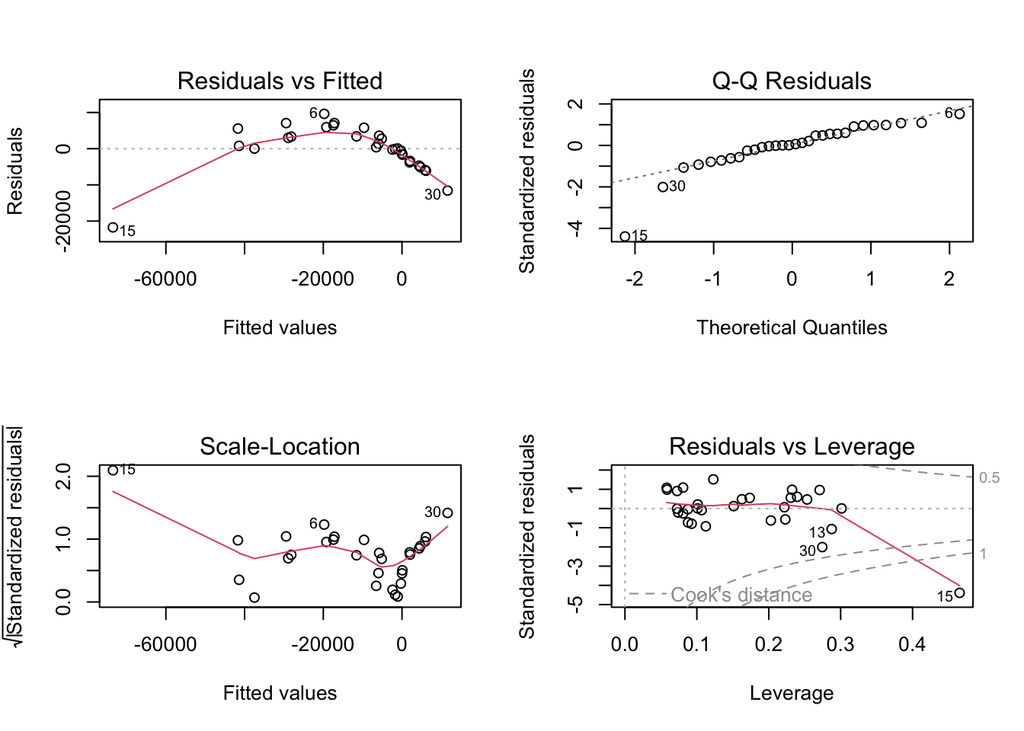

```r
# Diagnostic plots to see assumption violations
par(mfrow = c(2, 2))
plot(model_violation)
```

Compared to appropriate training data:

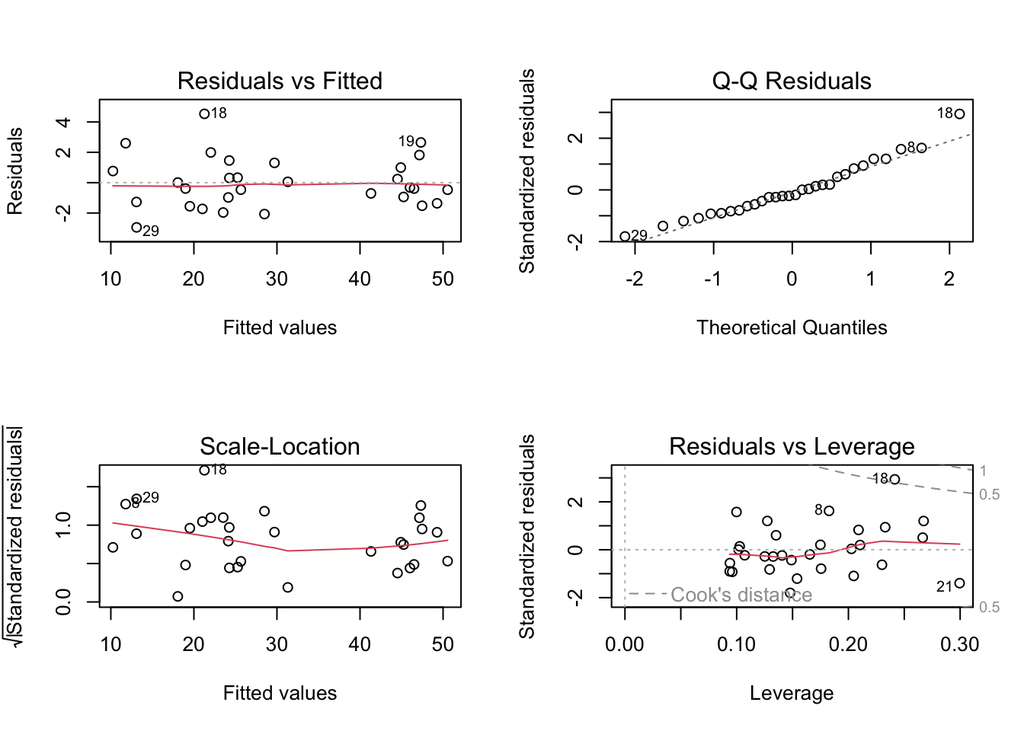

```r
par(mfrow = c(2, 2))
plot(model)
```

For more information on diagnostics plots, see (“Diagnostic Plots,” n.d.). For an explanation of leverage and Cook’s Distance, see (“Hat Matrix and Leverages in Classical Multiple Regression,” n.d.).

# 8 Bonus - Continuous Interactions

Let’s simulate an interaction between two continuous variables (complexion and undertone):

```r
#go back to our oriiginal data
# we don't want to use the bad data

skin_complexion <- df$skin_complexion
undertone <- df$undertone
skin_type <- df$skin_type

interaction_strength <- 0.5  # strength of the interaction
# Simulate foundation shade with interaction between complexion and undertone
foundation_shade <- 0.5 * skin_complexion + 3 * undertone +
                    interaction_strength * skin_complexion * undertone +
                    skin_type_effect[as.character(skin_type)] +
                    rnorm(n, sd = 2)  # error

# Combine into a data frame
sim_df <- data.frame(
  skin_complexion,
  undertone,
  skin_type,
  foundation_shade
)


interaction_model2 <- lm(foundation_shade ~ skin_complexion * undertone + skin_type, data = sim_df)
summary(interaction_model2)
```

```
##
## Call:
## lm(formula = foundation_shade ~ skin_complexion * undertone +
##     skin_type, data = sim_df)
##
## Residuals:
##     Min      1Q  Median      3Q     Max
## -3.8289 -0.8519  0.0945  1.0908  4.6076
##
## Coefficients:
##                           Estimate Std. Error t value Pr(>|t|)
## (Intercept)                -0.1273     3.9631  -0.032 0.974650
## skin_complexion             0.5066     0.0803   6.308  1.6e-06 ***
## undertone                   5.5881     4.9559   1.128 0.270650
## skin_typeDry               20.3751     0.9588  21.250  < 2e-16 ***
## skin_typeOily              -5.2112     1.0211  -5.104  3.2e-05 ***
## skin_complexion:undertone   0.4464     0.1032   4.326 0.000231 ***
## ---
## Signif. codes:  0 '***' 0.001 '**' 0.01 '*' 0.05 '.' 0.1 ' ' 1
##
## Residual standard error: 2.013 on 24 degrees of freedom
## Multiple R-squared:  0.9963, Adjusted R-squared:  0.9955
## F-statistic:  1293 on 5 and 24 DF,  p-value: < 2.2e-16
```

```r
plot_fits(df=sim_df, model=interaction_model2, type_colors = type_colors)
```

[interactive chart not shown]

This causes a **curved manifold** in the 3D predictor space because of the **multiplicative interaction term**:

$$\text{foundation_shade} = \beta_0
+ (\beta_1 \cdot \text{skin_complexion})
+ (\beta_2 \cdot \text{undertone})
+ (\beta_3 \cdot \text{skin_typeDry})
+ (\beta_4 \cdot \text{skin_typeOily})
+ (\beta_5 \cdot \text{skin_complexion} \times \text{undertone})$$

With interaction, the product term bends the surface into a saddle or curved manifold, because the effect of complexion depends on undertone and vice versa. Visually, this looks like a twist or warping in the fitted surface—a hallmark of interaction between two continuous variables in a linear model.

## 8.1 Deliverable

Print the design matrix for the continuous interaction model using the `model.matrix` function. Write out the linear equation for observations 1 and 2. Can you see why the hyperplane is curving?

```r
# your answer here
```

# References

“Diagnostic Plots.” n.d. https://library.virginia.edu/data/articles/diagnostic-plots.

“Hat Matrix and Leverages in Classical Multiple Regression.” n.d. https://stats.stackexchange.com/questions/208242/hat-matrix-and-leverages-in-classical-multiple-regression.

“Matrix Arithmetic - Matrix Algebra Review.” n.d. https://online.stat.psu.edu/statprogram/reviews/matrix-algebra/arithmetic.